# San Francisco - Police Incidents - Exercises

## BP.2

Produce the same barplot as in barplot 1. but this time order the bars from highest to lowest.

- `HINT`: you need to use the function `factor()` to turn the variable `Police Districts` into a factor variable.
- `HINT`: to find the appropriate order for the districts, you need to compute an `aux` dataset that counts the number of incidents in every district. For this:
  - Use `group_by()` + `summarize()` in combination with the function `n()`, which counts the number of rows in each group (in this case, the number of inciudents).
  - Arrange this result from largest to smallest number of incidents using `arrange()` and `desc()`
  - The notes on the basics of R explain how to use `group_by()`, `summarize()`, `arrange()` and `desc()`.
  - If you need help to use `n()`, google how to use the function `n()` in R.
- `HINT`: to produce the factor variable, use `factor()`. As an example, see the notebook 03 on graph customization, which contains a specific section on how to create factor variables for the purpose of ensuring the proper order of the levels in a graph.

Expected output:

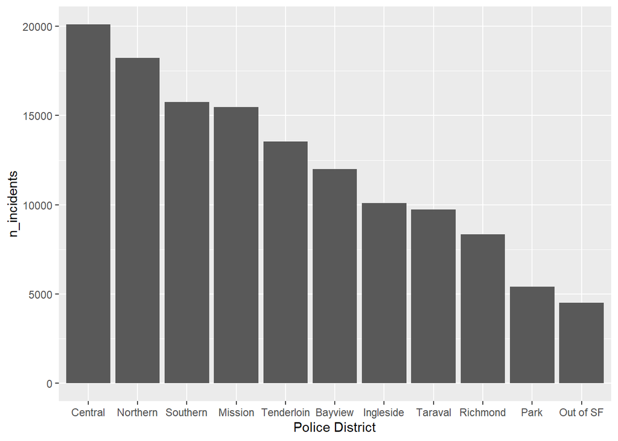

```r
aux <-
  sf_police %>%
    group_by(`Police District`) %>%
    summarise(
      n_incidents = n()
    ) %>%
    arrange(desc(n_incidents))

ordered_Distr = aux$`Police District`


aux <-
  aux %>%
  mutate(
     `Police District` = factor(`Police District`,
                                levels = ordered_Distr)
  )

aux %>%
  ggplot(aes(x = `Police District`, y = n_incidents)) +
  geom_bar(stat = "identity")
```

## Scatterplots

Group the dataset by `Analysis Neighborhood` and compute, for each neighborhood:

- The total number of incidents using `n()`. Call it `n_incidents`
- The `mean()` latitude of every incident in the neighborhood. Call it `mean_latitude`. This will be used as a representative latitude of the neighborhood.
- The `mean()` longitude of every incident in the neighborhood. Call it `mean_longitude`. This will be used as a representative longitude of the neighborhood.

Create one scatterplot for `latitude vs. n_incidents` and one for `longitude vs. n_incidents`. Is there a strong correlation between the number of incidents and either the latitude or the longitude?

```r
aux <-
  sf_police %>%
  group_by(`Analysis Neighborhood`) %>%
  summarize(
    n_incidents = n(),
    mean_latitude = mean(Latitude, na.rm = TRUE),
    mean_longitude = mean(Longitude, na.rm = TRUE)
  )
```

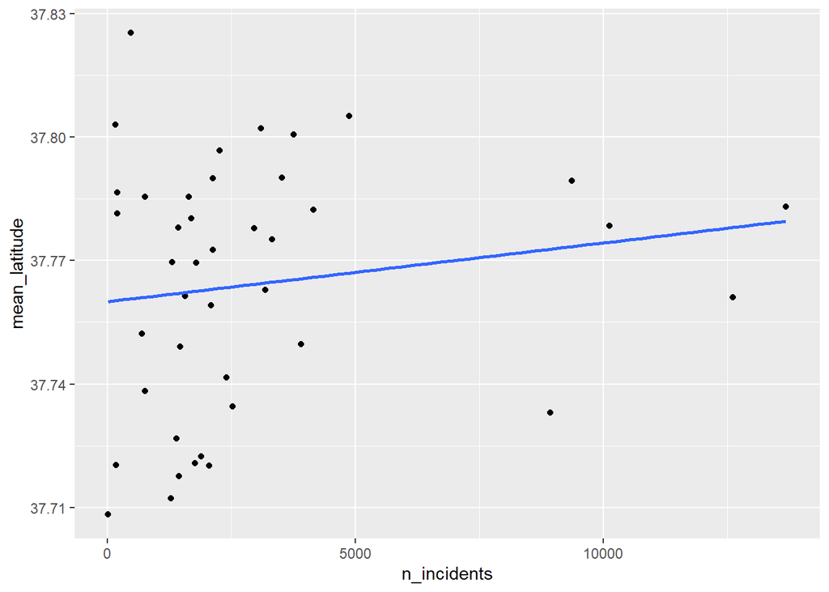

```r
aux %>%
  ggplot(aes(x = n_incidents, y = mean_latitude)) +
  geom_point() +
  geom_smooth(method = "lm", se = FALSE)
```

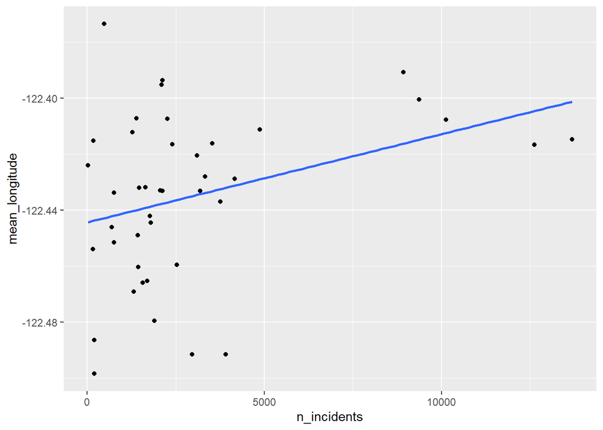

```r
aux %>%
  ggplot(aes(x = n_incidents, y = mean_longitude)) +
  geom_point() +
  geom_smooth(method = "lm", se = FALSE)
```

## LP. 1

We want to create lineplots of the number of incidents in each month over time for the different police districts (variable `Police District`).

For this:

1. `group_by()` the variables `Police District` and `month_fday`.
2. `summarize()` using the function `n()` to count the number of rows in each group (corresponding to the number of incidents in a district within a given month). Name this variable `n_incidents`.
3. `ungroup()` the result and store the result in an auxiliary variable `aux`.
4. Use this `aux` dataset to produce the graph below:
   - `HINT:` use `scale_x_date(breaks = "1 month", minor_breaks = "1 month")` to scale the x-axis accordingly.

The desired dataset structure is shown below:

```r
aux <-
sf_police %>%
  group_by(`Police District`, month_fday) %>%
  summarize(
    n_incidents = n()
  ) %>%
  ungroup()
```

```r
aux
```

```
# A tibble: 132 × 3
   `Police District` month_fday n_incidents
   <chr>             <date>           <int>
 1 Bayview           2022-01-01         977
 2 Bayview           2022-02-01         903
 3 Bayview           2022-03-01         949
 4 Bayview           2022-04-01         964
 5 Bayview           2022-05-01        1067
 6 Bayview           2022-06-01         953
 7 Bayview           2022-07-01        1065
 8 Bayview           2022-08-01        1080
 9 Bayview           2022-09-01        1042
10 Bayview           2022-10-01        1121
# … with 122 more rows
```

**Using aux, produce the graph below:**

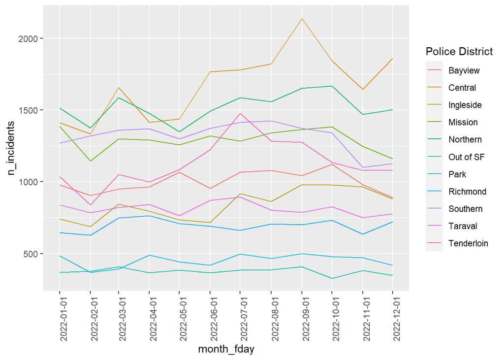

```r
aux %>%

  ggplot(aes(x = month_fday, y = n_incidents, color = `Police District`)) +

  geom_line() +

  scale_x_date(breaks = "1 month", minor_breaks = "1 month")  +

  theme(axis.text.x=element_text(angle = 90))
```

## LP. 2 - important `geom_step()`.

Starting from the `aux` dataset of the previous exercise, we are going to (**code for this given below**):

1. `arrange()` by both `Police District` and `month_fday`. This ensures that we have the observations within each `Police District` ordered chronologically.
2. `group_by()` again by both `Police District`.
3. Use `mutate()` and the function `cumsum()` to compute the **cummulated number of incidents in each district as time progresses**.
   - `NOTE:` we use `group_by()` + `mutate()` and not `group_by()` + `summarize()` because we want to preserve the number of rows in the dataset, yet want to perform the computation groupwise (we want the cummulative sum to be reset everytime the district changes).
   - **Be sure to understand this**. Check notebooks *00_B_1_tibbles_fundamentals* and *00_B_group_by_examples* and its *associated .pdf file* if you do not understand this.

```r
# IMPORTANT NOTE:
# The variable aux is assumed to be the aux dataframe produced
# for exercise LP.1.
# If this is not the case the code will not work properly.

aux2 <-
  aux %>%

    # Order the observations within each Police District
    # chronologically
    arrange(`Police District`, month_fday) %>%

    # Compute the cummulative sum of incidents for each
    # district
    group_by(`Police District`) %>%
    mutate(
      cumul_incidents = cumsum(n_incidents)
    )

aux2
```

```
# A tibble: 132 × 4
# Groups:   Police District [11]
   `Police District` month_fday n_incidents cumul_incidents
   <chr>             <date>           <int>           <int>
 1 Bayview           2022-01-01         977             977
 2 Bayview           2022-02-01         903            1880
 3 Bayview           2022-03-01         949            2829
 4 Bayview           2022-04-01         964            3793
 5 Bayview           2022-05-01        1067            4860
 6 Bayview           2022-06-01         953            5813
 7 Bayview           2022-07-01        1065            6878
 8 Bayview           2022-08-01        1080            7958
 9 Bayview           2022-09-01        1042            9000
10 Bayview           2022-10-01        1121           10121
# … with 122 more rows
```

**Use `aux2` to produce the graph below**. Importantly, use **`geom_step()` and not `geom_line()`** to generate this graph. The arguments and options are the same for both functions, just change the geom type.

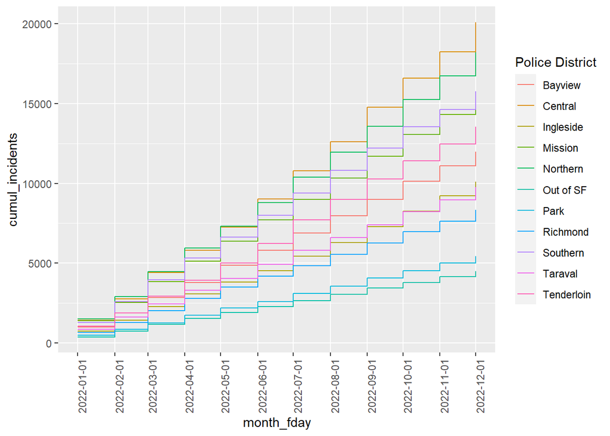

```r
aux2 %>%

  ggplot(aes(x = month_fday, y = cumul_incidents, color = `Police District`)) +

  geom_step() +

  scale_x_date(breaks = "1 month", minor_breaks = "1 month") +

  theme(axis.text.x=element_text(angle = 90))
```

**QUESTION why is this graph more appropriate to depict the cummulative sum over time?**

```r
geom_step() is better for cummulative sums and similar variables than geom_line()
because its shape when applied to this kind of cummulative data clearly signals
that we are performing a cummulative sum in which the value of the sum is an
aggregation over the entire month.

If we used geom_line instead it would appear that the cummulated incidents
increase linearly within each month, which is not the case. See the graph below
```

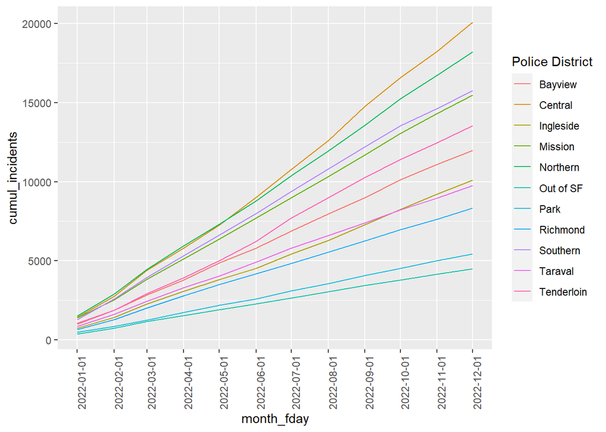

```r
aux2 %>%

  ggplot(aes(x = month_fday, y = cumul_incidents, color = `Police District`)) +

  geom_line() +

  scale_x_date(breaks = "1 month", minor_breaks = "1 month") +

  theme(axis.text.x=element_text(angle = 90))
```

## BoxP. 1 - somewhat advanced

**For this code, I am going to provide a description of the data transformation operations as well as the associated code**. It is **part of the exercise that you understand this code in detail**. Please **ask any question you have about this entire code**.

0. `filter()` the dataset to eliminate rows with value NA (no data) in the variable `Analysis Neighborhood`-
1. `group_by()` using the variable `Analysis Neighborhood`.
2. Compute the total number of incidents (`n_incidents`) in each neighborhood counting the number of rows within each of those groups, using the function `summarize()` in combination with `n()`
3. Store that intermediate result in a variable called `aux`.
4. Order `aux` by descending `n_incidents` using arrange and retain only the first 10 rows. We can do this, for example, using the function `head()` with argument 10 (`head(10)`). If you need to, look on google how to use the function `head()`. Store this result as `aux2`.
   - Example with a dataframe `df`: `df %>% head(5)`
5. Extract the column `Analysis Neighborhood` from `aux2` and store it in a new variable called `worst_nh`. Note that this variable is a vector.
   - If you do not know how to do this check notebook *00_B_tibbles_dplyr_fundamentals*, specifically how to *pull a single variable from a tibble/dataframe*.
6. Filter the dataset `sf_police` to contain only obervations from the neighborhoods in `worst_nh`.
7. Compute the number of incidents in each combination of `Analysis Neighborhood` and `week` using `group_by`, `summarize` and `n()`.
8. Redefine the variable `Analysis Neighborhood` so that it is a factor variable ordered following the list of worst neighborhoods `worst_nh`. For this you need to use `mutate()` and `factor()`.
   - If you do not know how to do this, check notebook *03_ggplot_customizing*.
- `HINT`: see the sessions on R basics to see how to use `arrange()` and `desc()`.
- `HINT`: see the sessions on the basics of R to see how to extract a column from a tibble and store it in vector form.

```r
aux <-

  sf_police %>%

  # Remove rows with NAs in the column Analysis Neighborhood
  filter(!is.na(`Analysis Neighborhood`)) %>%

  # Compute number of incidents in each neighborhood
  group_by(`Analysis Neighborhood`) %>%
  summarize(
    n_incidents = n()
  )
```

```r
aux2 <-
  aux %>%

  # Order from largest to smallest n_incidents
  arrange(desc(n_incidents))

aux2
```

```
# A tibble: 42 × 2
   `Analysis Neighborhood`        n_incidents
   <chr>                                <int>
 1 Tenderloin                           13685
 2 Mission                              12617
 3 South of Market                      10130
 4 Financial District/South Beach        9363
 5 Bayview Hunters Point                 8931
 6 North Beach                           4871
 7 Western Addition                      4158
 8 Sunset/Parkside                       3905
 9 Marina                                3760
10 Nob Hill                              3525
# … with 32 more rows
```

```r
# Extract the worst neighborhoods
worst_nh <- aux2 %>% head(10) %>% pull(`Analysis Neighborhood`)
worst_nh
```

```
 [1] "Tenderloin"                     "Mission"
 [3] "South of Market"                "Financial District/South Beach"
 [5] "Bayview Hunters Point"          "North Beach"
 [7] "Western Addition"               "Sunset/Parkside"
 [9] "Marina"                         "Nob Hill"
```

```r
aux3 <-
  sf_police %>%

    # Incidents only on 10 worst neighborhoods
    filter(
      (`Analysis Neighborhood` %in% worst_nh)
    ) %>%

    # group by neighborhood and week of the incident
    # We wanto to count the number of incidents during each
    # week in each neighborhood
    group_by(`Analysis Neighborhood`, week) %>%

    # count the number of incidents within each group
    summarize(
      n_inc_week = n()
    ) %>%

    # Remove grouping so that operations are not performed groupwise
    ungroup() %>%

    # Create a new factor variable to ensure proper ordering
    # of the neighborhoods
    mutate(
      `Analysis Neighborhood` = factor(`Analysis Neighborhood`,
                                       levels = worst_nh
                                      )
    )
```

Using `aux3`, produce the following graph:

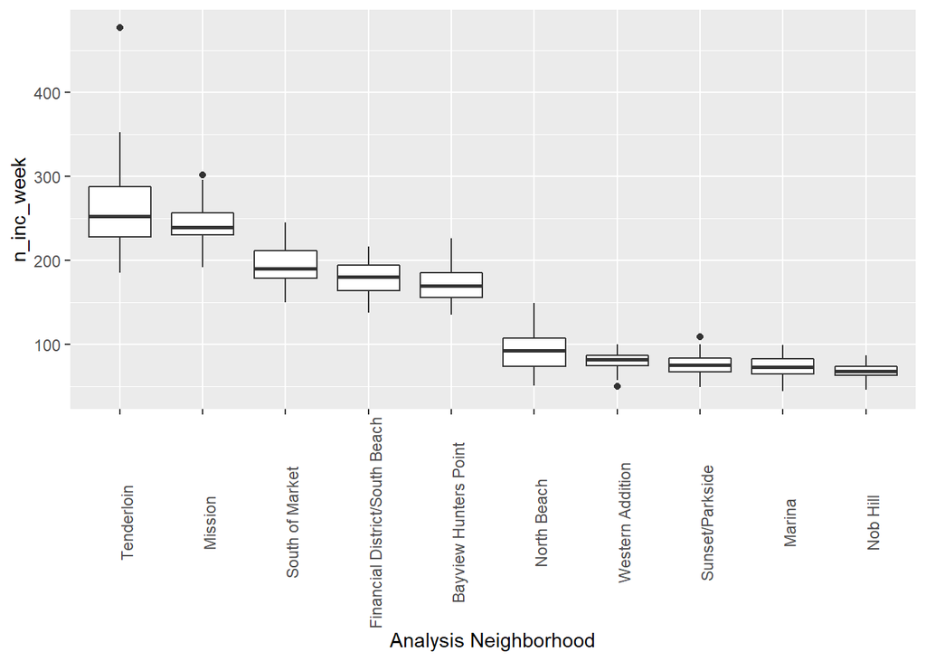

```r
aux3 %>%

  ggplot(aes(x = `Analysis Neighborhood`, y = n_inc_week)) +

  geom_boxplot()  +

  theme(axis.text.x=element_text(angle = 90))
```

**QUESTION use that graph to indicate which of the 10 worst neighborhoods are similar/could be grouped together in terms of weekly incidents**. Reason your answer based on the graph above… median values… inter-quantile ranges… spread of the data…

```r
We can clearly see three different groups in terms of the weekly
incidents.

Within each of these groups, the median of the weekly incidents is
within the interquartile range of the distribution of weekly incidents
in the other neighborhoods.

The exception to this is the group with the lowest median weekly incidents,
where the neighbor North Beach exhibits a median value of weelky incidents
that is a little bit outside the IQR of the other neighborhoods. Specific
analysis could be performed to see if this difference is statistically
significant and, perhaps most importantly, whether it is relevant in terms
of the research being performed.
```

## Heatmaps

Exercises on heatmaps based on this dataset will be provided.

For the time being do exercise HM.2 on notebook 2_lineplots_boxplots_heatmaps.